# Obstetrics and Periodontal Therapy (OPT) RCT treatment effect on gestational age

Hajin Jang

12/6/2023

### This analysis uses clinical trial data to assess baseline balance between treatment groups and to evaluate the effect of treatment on gestational age using parametric and nonparametric statistical tests.

# Data

Read in the data from Excel

```r
library(tidyverse)
library(readxl)
library(emmeans)
opt <- read_xlsx("OPT_Study_Person-level_Data.xlsx")
```

```r
xtabs(~ `Birth outcome`, data=opt)
```

```
## Birth outcome
## Elective abortion        Live birth        Lost to FU    Non-live birth
##                 2               793                 9                19
```

Filter the data set to only live births

```r
opt <- opt %>%
  filter(`Birth outcome` == "Live birth")
```

# Part 1: Associations with treatment group assignment

## Clinic site by treatment group

```r
# numerical summary
tbl1 <- xtabs(~Clinic + Group , data = opt )
tbl1
```

```
##       Group
## Clinic   C   T
##     KY  98 105
##     MN 122 122
##     MS  91  94
##     NY  80  81
```

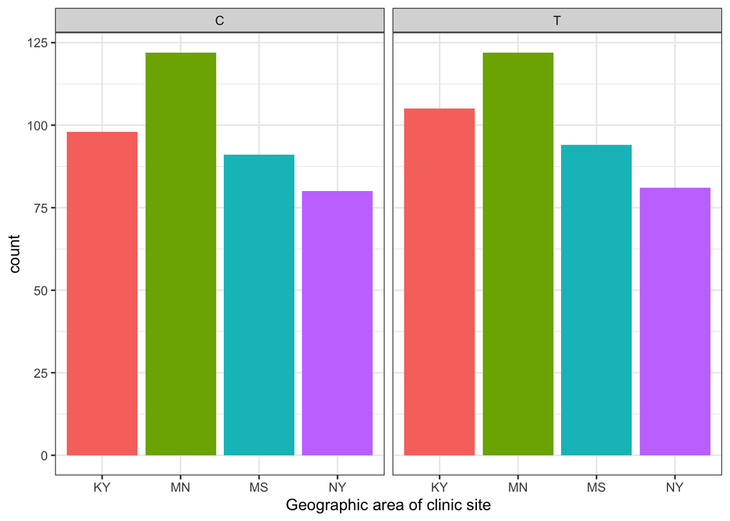

```r
# graphical (visual) summary
opt %>% ggplot(aes(x = Clinic, fill = Clinic)) +
  facet_wrap(.~ Group) +
  geom_histogram(stat = "count") +
  labs(x = "Geographic area of clinic site") +
  theme_bw() +
  theme(legend.position = "none") # suppress legend
```

```r
# statistical test
xsq = chisq.test(tbl1,correct = F)
xsq$expected
```

```
##       Group
## Clinic         C         T
##     KY 100.09206 102.90794
##     MN 120.30769 123.69231
##     MS  91.21690  93.78310
##     NY  79.38335  81.61665
```

```r
chisq.test(tbl1,correct = F)
```

```
##
##  Pearson's Chi-squared test
##
## data:  tbl1
## X-squared = 0.14368, df = 3, p-value = 0.9861
```

**Justification of test:** Treatment group is a categorical variable with 2 levels. Clinic site is a categorical variable with 4 levels. Thus, I drew a contingency table for the numerical summary, side-by-side bar charts for the graphical summary, and conducted a Chi-squared test, as the expected count of cells is all bigger than 5.

## Age by treatment group

```r
# numerical summary
opt %>%
  group_by(Group) %>%
  summarise(n= n(),
            mean = mean(Age),
            med = median(Age),
            var = var(Age))
```

| Group | n | mean | med | var |
| --- | --- | --- | --- | --- |
| C | 391 | 25.92583 | 25 | 30.4432 |
| T | 402 | 26.06965 | 25 | 31.8904 |

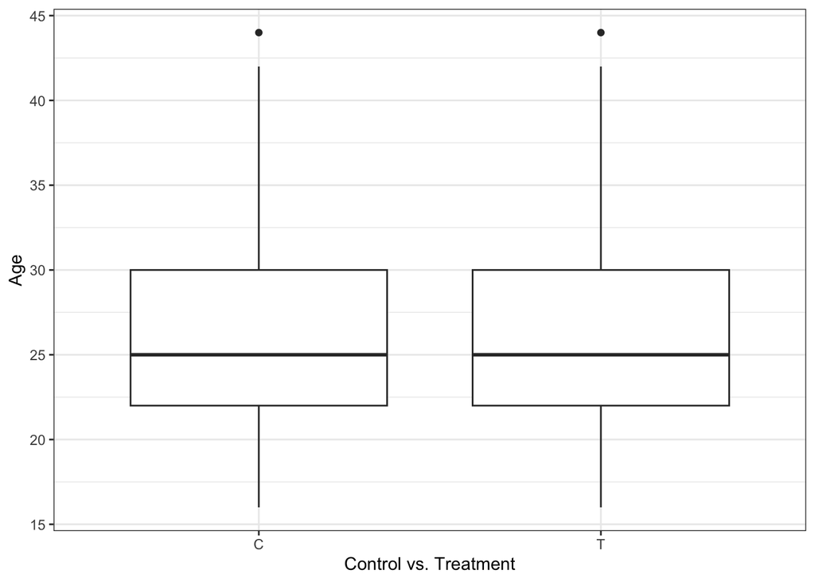

```r
# graphical (visual) summary
# boxplot
opt %>%
 ggplot(aes(x = Group, y = Age)) +
  geom_boxplot() +
  theme_bw() +
  labs(x = "Control vs. Treatment", y = "Age")
```

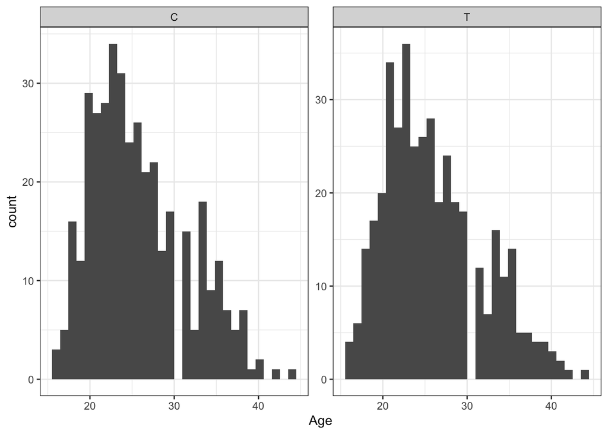

```r
# side-by-side histograms
opt %>%
 ggplot(aes(x = Age, fill = Age)) +
  geom_histogram() +
  theme_bw() +
  labs(x = "Age") +
  facet_wrap(.~ Group, scales = "free_y")
```

```r
# statistical test

xtabs(~Group, data = opt)
```

```
## Group
##   C   T
## 391 402
```

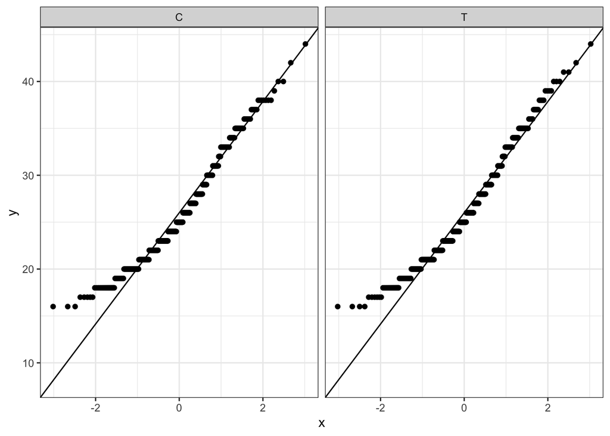

```r
opt %>%
  ggplot(aes(sample = Age)) +
  geom_qq() +
  geom_qq_line() +
  theme_bw() +
  facet_wrap(.~ Group)
```

```r
var.test(Age~Group, data = opt)
```

```
##
##  F test to compare two variances
##
## data:  Age by Group
## F = 0.95462, num df = 390, denom df = 401, p-value = 0.6448
## alternative hypothesis: true ratio of variances is not equal to 1
## 95 percent confidence interval:
##  0.7837095 1.1631210
## sample estimates:
## ratio of variances
##          0.9546197
```

```r
t.test(Age ~ Group, data = opt)
```

```
##
##  Welch Two Sample t-test
##
## data:  Age by Group
## t = -0.36275, df = 790.98, p-value = 0.7169
## alternative hypothesis: true difference in means between group C and group T is not equal to 0
## 95 percent confidence interval:
##  -0.9220802  0.6344391
## sample estimates:
## mean in group C mean in group T
##        25.92583        26.06965
```

**Justification of test:** Treatment group is a categorical variable with 2 levels. Age is a continuous variable. Thus, I calculated mean, median and variance of age by treatment group for the numerical summary, and drew side-by-side histograms and boxplots for the graphical summary. I conducted a two-sample t test, as they are random samples, the variances of two groups are not different, and both groups are approximately normally distributed.

## Education by treatment group

```r
# numerical summary
tbl2 <- xtabs(~Education + Group , data = opt )
tbl2
```

```
##            Group
## Education     C   T
##   8-12 yrs  232 229
##   LT 8 yrs   72  78
##   MT 12 yrs  87  95
```

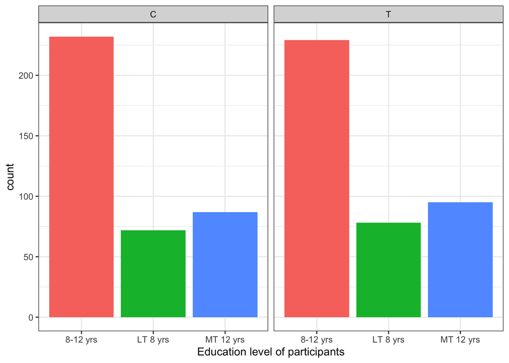

```r
# graphical (visual) summary
opt %>% ggplot(aes(x = Education, fill = Education)) +
  facet_wrap(.~ Group) +
  geom_histogram(stat = "count") +
  labs(x = "Education level of participants") +
  theme_bw() +
  theme(legend.position = "none") # suppress legend
```

```r
# statistical test
xsq2 = chisq.test(tbl2,correct = F)
xsq2$expected
```

```
##            Group
## Education           C         T
##   8-12 yrs  227.30265 233.69735
##   LT 8 yrs   73.95965  76.04035
##   MT 12 yrs  89.73770  92.26230
```

```r
chisq.test(tbl2,correct = F)
```

```
##
##  Pearson's Chi-squared test
##
## data:  tbl2
## X-squared = 0.45867, df = 2, p-value = 0.7951
```

**Justification of test:** Treatment group is a categorical variable with 2 levels. Education is a categorical variable with 3 levels. Thus, I drew a contingency table for the numerical summary, side-by-side bar charts for the graphical summary, and conducted a Chi-squared test, as the expected count of cells is all bigger than 5.

## BMI by treatment group

```r
# numerical summary
opt %>%
  group_by(Group) %>%
  summarise(n= n(),
            mean = mean(BMI),
            med = median(BMI),
            var = var(BMI))
```

| Group | n | mean | med | var |
| --- | --- | --- | --- | --- |
| C | 391 | NA | NA | NA |
| T | 402 | NA | NA | NA |

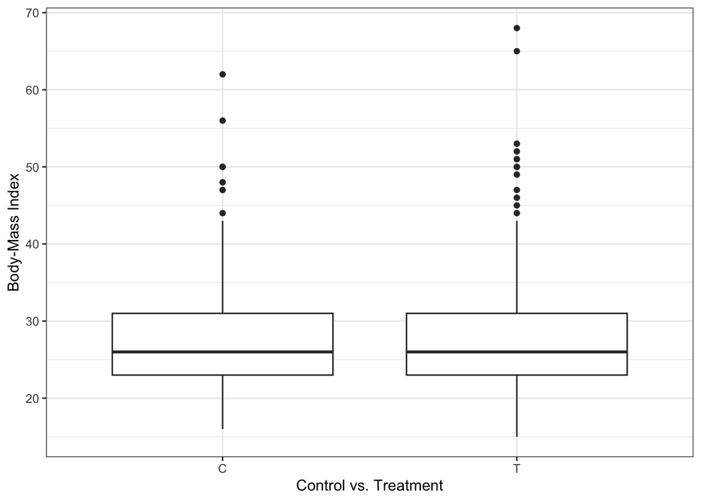

```r
# graphical (visual) summary
# boxplot
opt %>%
 ggplot(aes(x = Group, y = BMI)) +
  geom_boxplot() +
  theme_bw() +
  labs(x = "Control vs. Treatment", y = "Body-Mass Index")
```

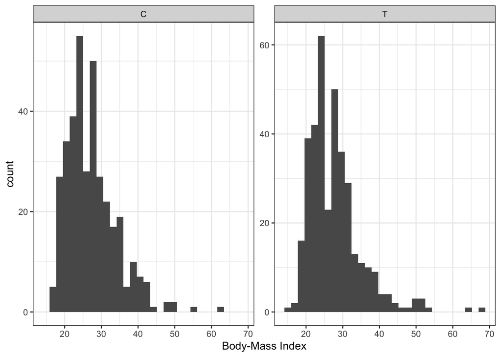

```r
# side-by-side histograms
opt %>%
 ggplot(aes(x = BMI, fill = BMI)) +
  geom_histogram() +
  theme_bw() +
  labs(x = "Body-Mass Index") +
  facet_wrap(.~ Group, scales = "free_y")
```

```r
# statistical test
xtabs(~Group, data = opt)
```

```
## Group
##   C   T
## 391 402
```

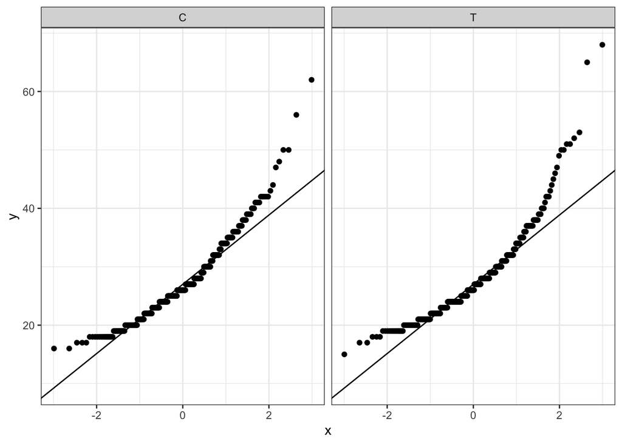

```r
opt %>%
  ggplot(aes(sample = BMI)) +
  geom_qq() +
  geom_qq_line() +
  theme_bw() +
  facet_wrap(.~ Group)
```

```r
var.test(BMI ~ Group, data = opt)
```

```
##
##  F test to compare two variances
##
## data:  BMI by Group
## F = 0.9094, num df = 357, denom df = 363, p-value = 0.3683
## alternative hypothesis: true ratio of variances is not equal to 1
## 95 percent confidence interval:
##  0.7394795 1.1185771
## sample estimates:
## ratio of variances
##          0.9094038
```

```r
t.test(BMI ~ Group, data = opt)
```

```
##
##  Welch Two Sample t-test
##
## data:  BMI by Group
## t = -0.61854, df = 719.32, p-value = 0.5364
## alternative hypothesis: true difference in means between group C and group T is not equal to 0
## 95 percent confidence interval:
##  -1.3472326  0.7017049
## sample estimates:
## mean in group C mean in group T
##        27.41899        27.74176
```

```r
# nonparametrix test
wilcox.test(BMI ~ Group, data = opt, correct=F)
```

```
##
##  Wilcoxon rank sum test
##
## data:  BMI by Group
## W = 63957, p-value = 0.6682
## alternative hypothesis: true location shift is not equal to 0
```

**Justification of test:** Treatment group is a categorical variable with 2 levels. BMI is a continuous variable. Thus, I calculated mean, median and variance of BMI by treatment group for the numerical summary, and drew side-by-side histograms and boxplots for the graphical summary. I conducted both two-sample t test and wilcoxon rank sum test, as they are random samples, the variances of two groups are not different, but both groups didn’t fit well with normal lines in the qq plot.

## Summary of Part 1

A Chi-squared test of the clinic site by treatment group was not statistically significant (X-squared=0.14, p-value=0.99). A two sample t-test of age by treatment group was not statistically significant (t=-0.36, 95% CI=(-0.92, 0.63), p-value=0.72). A Chi-squared test of the education by treatment group was not statistically significant (X-squared=0.46, p-value=0.7951). A two sample t-test of BMI by treatment group was not statistically significant (t=-0.62, 95% CI=(-1.35, 0.70), p-value=0.54). A Wilcoxon rank sum test of BMI by treatment group was not statistically significant (W=63957, p-value=0.6682).

As all of the above covariates were not statistically significantly associated with treatment group assignment (exposure), we were allowed not to conduct multivariable analysis including the variables as covariates in the main analysis.

# Part 2: Primary outcome analysis

## Gestational age by treatment group

```r
# numerical summary
opt %>%
  group_by(Group) %>%
  summarise(n= n(),
            mean = mean(`GA at outcome`),
            med = median(`GA at outcome`),
            var = var(`GA at outcome`))
```

| Group | n | mean | med | var |
| --- | --- | --- | --- | --- |
| C | 391 | 273.2481 | 275 | 224.4332 |
| T | 402 | 272.5597 | 276 | 252.0825 |

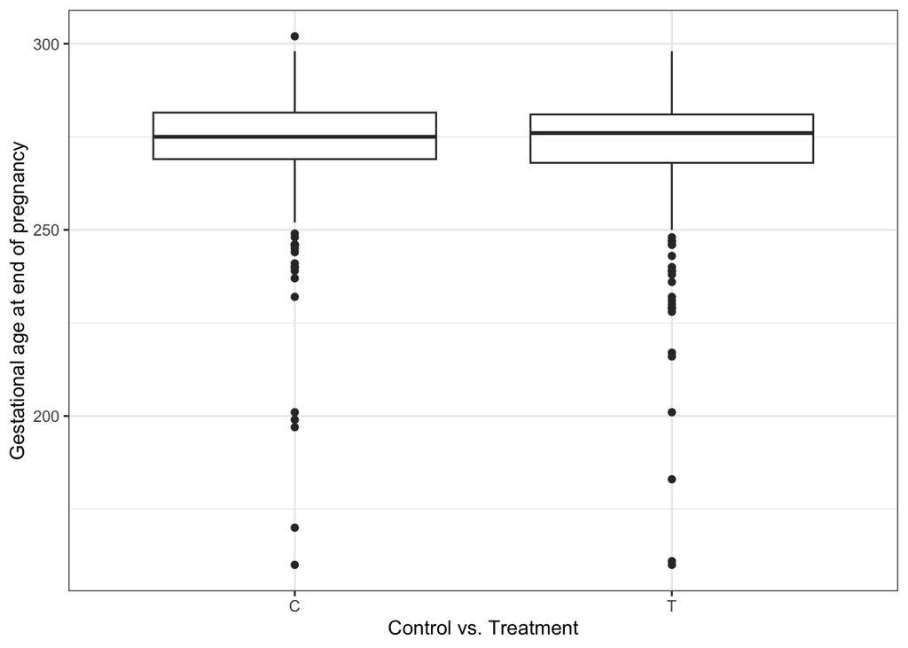

```r
# graphical (visual) summary
# boxplot
opt %>%
 ggplot(aes(x = Group, y = `GA at outcome`)) +
  geom_boxplot() +
  theme_bw() +
  labs(x = "Control vs. Treatment", y = "Gestational age at end of pregnancy")
```

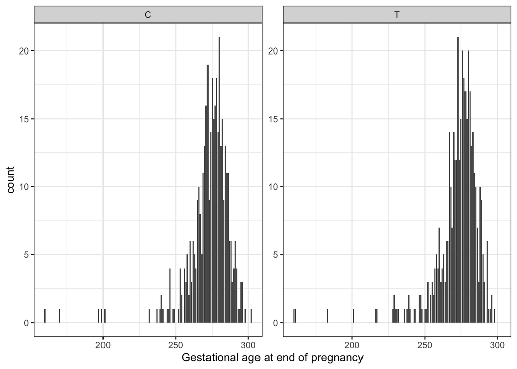

```r
# side-by-side histograms
opt %>%
 ggplot(aes(x = `GA at outcome`, fill = `GA at outcome`)) +
  geom_histogram(stat = 'count', binwidth = 1) +
  theme_bw() +
  labs(x = "Gestational age at end of pregnancy") +
  facet_wrap(~ Group, scales = "free_y")
```

```r
# statistical test
xtabs(~Group, data = opt)
```

```
## Group
##   C   T
## 391 402
```

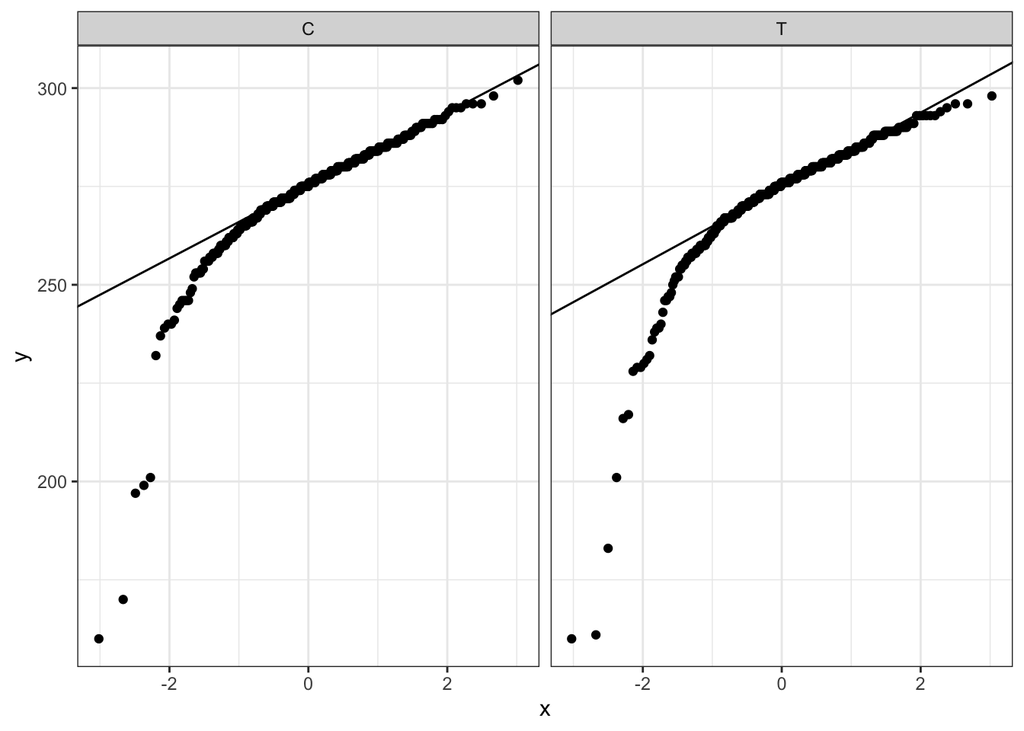

```r
opt %>%
  ggplot(aes(sample = `GA at outcome`)) +
  geom_qq() +
  geom_qq_line() +
  theme_bw() +
  facet_wrap(.~ Group)
```

```r
var.test(`GA at outcome` ~ Group, data = opt)
```

```
##
##  F test to compare two variances
##
## data:  GA at outcome by Group
## F = 0.89032, num df = 390, denom df = 401, p-value = 0.2488
## alternative hypothesis: true ratio of variances is not equal to 1
## 95 percent confidence interval:
##  0.7309188 1.0847731
## sample estimates:
## ratio of variances
##          0.8903165
```

```r
t.test(`GA at outcome` ~ Group, data = opt)
```

```
##
##  Welch Two Sample t-test
##
## data:  GA at outcome by Group
## t = 0.62812, df = 790.28, p-value = 0.5301
## alternative hypothesis: true difference in means between group C and group T is not equal to 0
## 95 percent confidence interval:
##  -1.462903  2.839664
## sample estimates:
## mean in group C mean in group T
##        273.2481        272.5597
```

```r
# nonparametrix test
wilcox.test(`GA at outcome` ~ Group, data = opt, correct=F)
```

```
##
##  Wilcoxon rank sum test
##
## data:  GA at outcome by Group
## W = 79482, p-value = 0.7822
## alternative hypothesis: true location shift is not equal to 0
```

**Justification of test:** Treatment group is a categorical variable with 2 levels. Gestational age is a continuous variable. Thus, I calculated mean, median and variance of gestational age by treatment group for the numerical summary, and drew side-by-side histograms and boxplots for the graphical summary. I conducted both two-sample t test and wilcoxon rank sum test, as they are random samples, the variances of two groups are not different, but both groups didn’t fit well with normal lines in the qq plot.

## Gestational age by participants age

```r
# numerical summary
opt %>%
  select(`GA at outcome`, Age) %>%
  summarise(correlation = cor(`GA at outcome`, Age))
```

| correlation |
| --- |
| -0.04801994 |

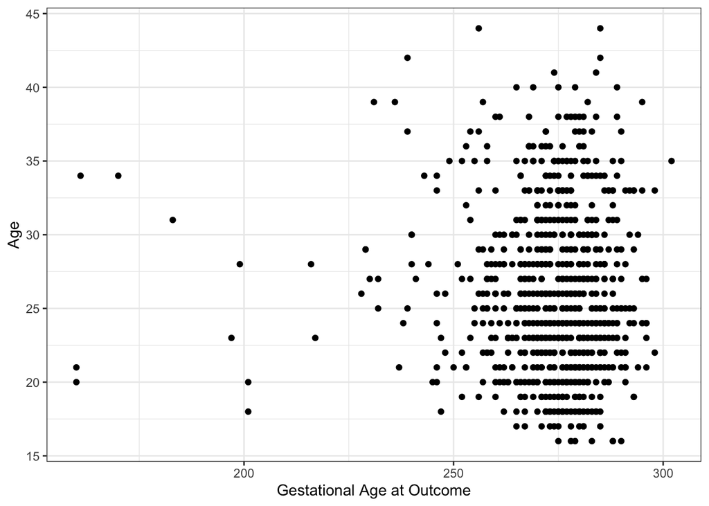

```r
# graphical (visual) summary
opt %>%
  ggplot(aes(x = `GA at outcome`, y = Age)) +
  geom_point() +
  labs(x = "Gestational Age at Outcome", y = "Age") +
  theme_bw()
```

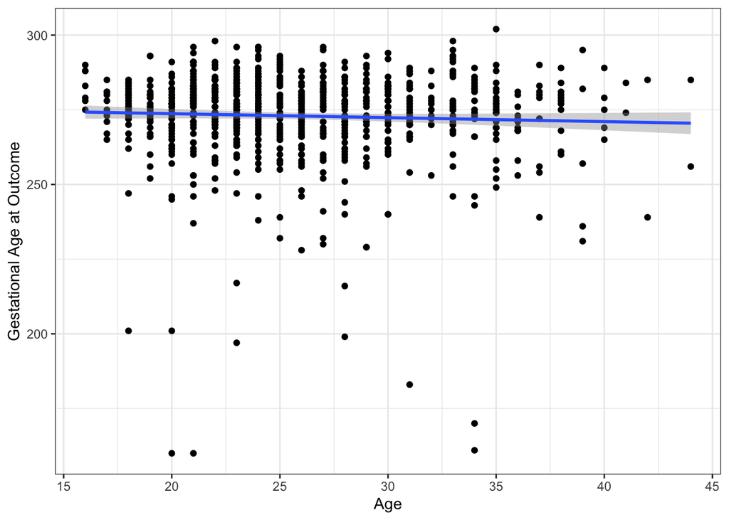

```r
opt %>%
  ggplot(aes(x = Age, y = `GA at outcome`)) +
  geom_point() +
  geom_smooth(method = 'lm') +
  labs(x = "Age", y = "Gestational Age at Outcome") +
  theme_bw()
```

```r
# statistical test
fit <- lm(`GA at outcome` ~ Age, data = opt)

# estimated coefficients, t-tests, and global F-test
summary(fit)
```

```
##
## Call:
## lm(formula = `GA at outcome` ~ Age, data = opt)
##
## Residuals:
##      Min       1Q   Median       3Q      Max
## -113.696   -4.500    2.765    8.429   30.296
##
## Coefficients:
##              Estimate Std. Error t value Pr(>|t|)
## (Intercept) 276.35237    2.61208 105.798   <2e-16 ***
## Age          -0.13282    0.09823  -1.352    0.177
## ---
## Signif. codes:  0 '***' 0.001 '**' 0.01 '*' 0.05 '.' 0.1 ' ' 1
##
## Residual standard error: 15.43 on 791 degrees of freedom
## Multiple R-squared:  0.002306,   Adjusted R-squared:  0.001045
## F-statistic: 1.828 on 1 and 791 DF,  p-value: 0.1767
```

```r
#confidence interval
confint(fit)
```

```
##                   2.5 %       97.5 %
## (Intercept) 271.2249443 281.47979712
## Age          -0.3256554   0.06000768
```

**Justification of test:** Gestational age and participants age are both continuous variables. Thus, I calculated the correlation between gestational age and participants age for the numerical summary, drew a scatterplot for the graphical summary, and conducted a linear regression analysis.

## Gestational age by clinic site

```r
# numerical summary
opt %>%
  group_by(Clinic) %>%
  summarise(n= n(),
            mean = mean(`GA at outcome`),
            med = median(`GA at outcome`),
            var = var(`GA at outcome`))
```

| Clinic | n | mean | med | var |
| --- | --- | --- | --- | --- |
| KY | 203 | 272.4236 | 275 | 168.4731 |
| MN | 244 | 275.3197 | 278 | 246.5805 |
| MS | 185 | 269.7459 | 272 | 267.2449 |
| NY | 161 | 273.4534 | 276 | 263.8744 |

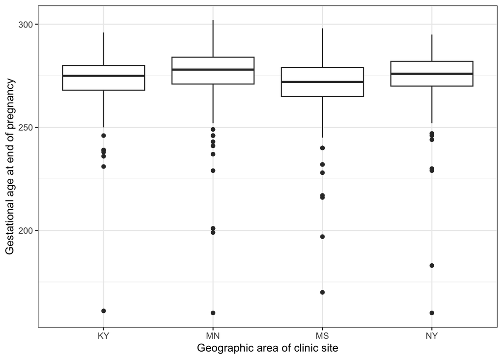

```r
# graphical (visual) summary
# boxplot
opt %>%
 ggplot(aes(x = Clinic, y = `GA at outcome`)) +
  geom_boxplot() +
  theme_bw() +
  labs(x = "Geographic area of clinic site", y = "Gestational age at end of pregnancy")
```

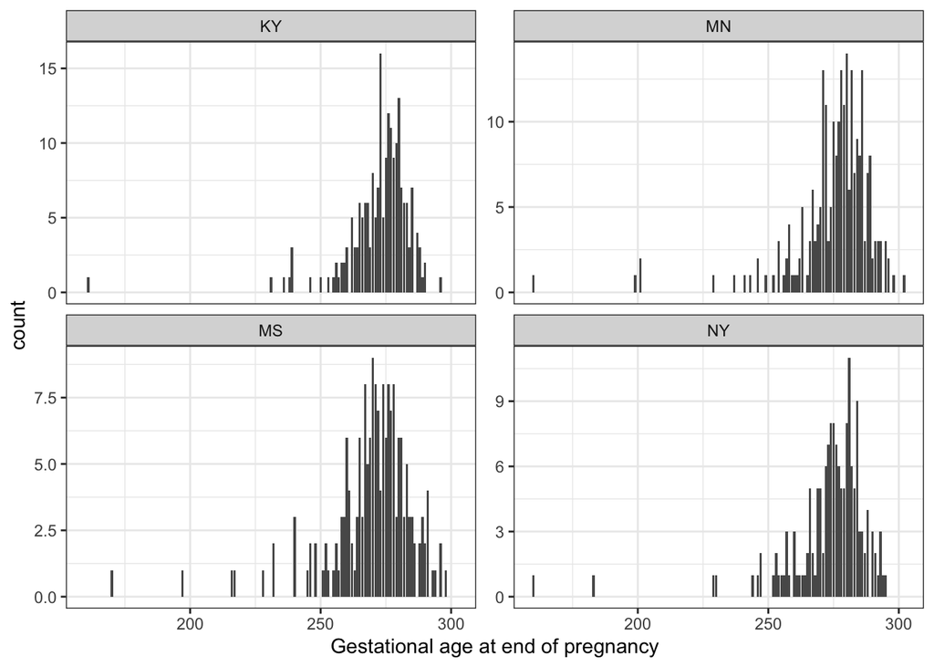

```r
# side-by-side histograms
opt %>%
 ggplot(aes(x = `GA at outcome`, fill = `GA at outcome`)) +
  geom_histogram(stat = 'count', binwidth = 1) +
  theme_bw() +
  labs(x = "Gestational age at end of pregnancy") +
  facet_wrap(~ Clinic, scales = "free_y")
```

```r
# statistical test
## ANOVA ##

# check conditions
# sample sizes table
opt %>% group_by(Clinic) %>% summarize(n = n(), age_mean= mean(`GA at outcome`, na.rm=TRUE), age_sd= sd(`GA at outcome`, na.rm=TRUE))
```

| Clinic | n | age_mean | age_sd |
| --- | --- | --- | --- |
| KY | 203 | 272.4236 | 12.97972 |
| MN | 244 | 275.3197 | 15.70288 |
| MS | 185 | 269.7459 | 16.34763 |
| NY | 161 | 273.4534 | 16.24421 |

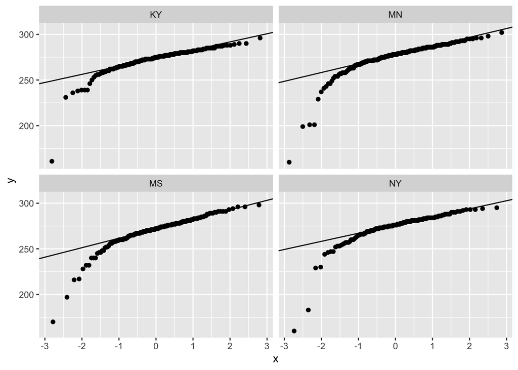

```r
# qqplots for each group if sample sizes are small
opt %>% ggplot(aes(sample = `GA at outcome`)) + geom_qq() + geom_qq_line() + facet_wrap(.~Clinic)
```

```r
#ANOVA
model <- lm(`GA at outcome` ~ Clinic, data = opt)
anova(model)
```

|  | Df | Sum Sq | Mean Sq | F value | Pr(>F) |
| --- | --- | --- | --- | --- | --- |
| Clinic | 3 | 3364.337 | 1121.4457 | 4.773948 | 0.002642219 |
| Residuals | 789 | 185343.592 | 234.9095 | NA | NA |

```r
# multiple-testing correction
bonf.model <- emmeans(model, pairwise ~ Clinic, adjust = "bonferroni")
bonf.model$contrasts
```

```
##  contrast estimate   SE  df t.ratio p.value
##  KY - MN     -2.90 1.46 789  -1.989  0.2823
##  KY - MS      2.68 1.56 789   1.719  0.5162
##  KY - NY     -1.03 1.62 789  -0.637  1.0000
##  MN - MS      5.57 1.49 789   3.730  0.0012
##  MN - NY      1.87 1.56 789   1.199  1.0000
##  MS - NY     -3.71 1.65 789  -2.244  0.1505
##
## P value adjustment: bonferroni method for 6 tests
```

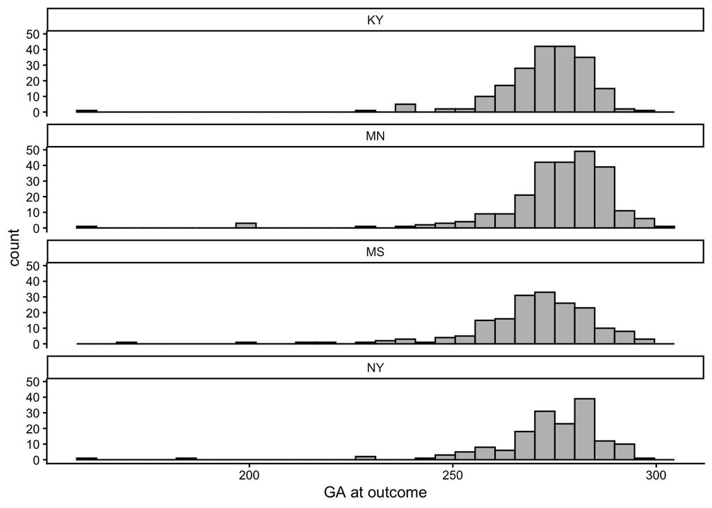

```r
## Kruskal-Wallis ##

# check conditions
opt %>%
  ggplot(aes(x = `GA at outcome`)) +
  geom_histogram(color="black", fill="gray") +
  facet_wrap(. ~ Clinic, nrow = 4) +
  theme_classic()
```

```r
# run test
kruskal.test(`GA at outcome` ~ Clinic, data = opt)
```

```
##
##  Kruskal-Wallis rank sum test
##
## data:  GA at outcome by Clinic
## Kruskal-Wallis chi-squared = 32.036, df = 3, p-value = 5.142e-07
```

**Justification of test:** Clinic site is a categorical variable with 4 levels. Gestational age is a continuous variable. Thus, I calculated mean, median and variance of gestational age by clinic site for the numerical summary, and drew side-by-side histograms and boxplots for the graphical summary. I conducted both ANOVA and Kruskal-Wallis test, as populations by clinic site are independent, random samples, assumed to have equal population variances, but didn’t fit well with normal lines in the qq plot.

## Summary of Part 2

A two sample t-test of gestational age by treatment group was not statistically significant (t=0.63, 95% CI=(-1.46, 2.84), p-value=0.5301). A Wilcoxon rank sum test of gestational age by treatment group was also not statistically significant (W=79482, p-value=0.7822). A correlation of gestational age and participants age was -0.05 and the linear association was not statistically significant (p-value=0.177, beta of age=-0.13, 95% CI=(-0.3257, 0.0600)).

The result of the ANOVA analysis of gestational age by clinic site was statistically significant (F=4.7739, p-value=0.002642). After multiple-testing corrections with the Bonferroni method, it was found that the gestational age was significantly different between the clinic site of MN and MS (p-value=0.0012). The result of Kruskal-Wallis rank sum test was also significant (p-value=5.142e-07).